# Chapter 2 Subsetting and Sorting

```python
import pandas as pd

# Read titanic dataset
tnc = pd.read_csv("./datasets/titanic.csv")

# Print dataframe
tnc.head()
```

|  | pclass | survived | name | gender | age | sibsp | parch | ticket | fare | cabin | embarked | boat | body | home.dest |
| --- | --- | --- | --- | --- | --- | --- | --- | --- | --- | --- | --- | --- | --- | --- |
| 0 | 1 | 1 | Allen, Miss. Elisabeth Walton | female | 29 | 0 | 0 | 24160 | 211.3375 | B5 | S | 2 | ? | St Louis, MO |
| 1 | 1 | 1 | Allison, Master. Hudson Trevor | male | 0.9167 | 1 | 2 | 113781 | 151.55 | C22 C26 | S | 11 | ? | Montreal, PQ / Chesterville, ON |
| 2 | 1 | 0 | Allison, Miss. Helen Loraine | female | 2 | 1 | 2 | 113781 | 151.55 | C22 C26 | S | ? | ? | Montreal, PQ / Chesterville, ON |
| 3 | 1 | 0 | Allison, Mr. Hudson Joshua Creighton | male | 30 | 1 | 2 | 113781 | 151.55 | C22 C26 | S | ? | 135 | Montreal, PQ / Chesterville, ON |
| 4 | 1 | 0 | Allison, Mrs. Hudson J C (Bessie Waldo Daniels) | female | 25 | 1 | 2 | 113781 | 151.55 | C22 C26 | S | ? | ? | Montreal, PQ / Chesterville, ON |

```python
# Info about columns, datatypes, non-null columns, and total size
tnc.info()
```

```
<class 'pandas.core.frame.DataFrame'>
RangeIndex: 1309 entries, 0 to 1308
Data columns (total 14 columns):
 #   Column     Non-Null Count  Dtype
---  ------     --------------  -----
 0   pclass     1309 non-null   int64
 1   survived   1309 non-null   int64
 2   name       1309 non-null   object
 3   gender     1309 non-null   object
 4   age        1309 non-null   object
 5   sibsp      1309 non-null   int64
 6   parch      1309 non-null   int64
 7   ticket     1309 non-null   object
 8   fare       1309 non-null   object
 9   cabin      1309 non-null   object
 10  embarked   1309 non-null   object
 11  boat       1309 non-null   object
 12  body       1309 non-null   object
 13  home.dest  1309 non-null   object
dtypes: int64(4), object(10)
memory usage: 143.3+ KB
```

```python
# Shape of the dataframe
tnc.shape
```

```
(1309, 14)
```

## Selecting column

We can select one column from a Dataframe using the following two syntax:

1) **Dataframe.column_name**

2) **Dataframe["column_name"]** or **Dataframe["column_name"]**

```python
# Extracting age column from the data
tnc.age
```

```
0           29
1       0.9167
2            2
3           30
4           25
         ...
1304      14.5
1305         ?
1306      26.5
1307        27
1308        29
Name: age, Length: 1309, dtype: object
```

```python
# Extracting name column from the dataframe
tnc["name"]
```

```
0                         Allen, Miss. Elisabeth Walton
1                        Allison, Master. Hudson Trevor
2                          Allison, Miss. Helen Loraine
3                  Allison, Mr. Hudson Joshua Creighton
4       Allison, Mrs. Hudson J C (Bessie Waldo Daniels)
                             ...
1304                               Zabour, Miss. Hileni
1305                              Zabour, Miss. Thamine
1306                          Zakarian, Mr. Mapriededer
1307                                Zakarian, Mr. Ortin
1308                                 Zimmerman, Mr. Leo
Name: name, Length: 1309, dtype: object
```

### Why second syntax is better than first?

First syntax: **Dataframe.column_name**

Second syntax: **Dataframe["column_name"]**

Because there can be many instances where the dot operator syntax may not work.

One such example is that we cannot access the column "home.dest" using the dot operator.

```python
# Using first syntax
# tnc.home.dest

# Python looks for 'dest' attribute in 'home' attribute of 'tnc'.
# It first looks for 'home' which is not an attribute and hence results in error
```

```python
# Extracting "home.dest" column using the second syntax
tnc["home.dest"]
```

```
0                          St Louis, MO
1       Montreal, PQ / Chesterville, ON
2       Montreal, PQ / Chesterville, ON
3       Montreal, PQ / Chesterville, ON
4       Montreal, PQ / Chesterville, ON
                     ...
1304                                  ?
1305                                  ?
1306                                  ?
1307                                  ?
1308                                  ?
Name: home.dest, Length: 1309, dtype: object
```

## Selecting multiple columns

We can select multiple columns using the square bracket syntax:

**Dataframe[["col1_name", "col2_name", ...., "colN_name"]]**

```python
# Describe the statistical information about the columns name, age and home.dest of first 25 members in the titanic dataframe

# Extract first 25 members
tnc_25 = tnc.head(25)

# Select the columns name, age and home.dest using square bracket syntax
tnc_cols = tnc_25[["name", "age", "home.dest"]]

# Describe the columns
tnc_cols.describe()

# This can also be achieved in a single line using Method Chaining
# tnc.head(25)[["name", "age", "home.dest"]].describe()
```

|  | name | age | home.dest |
| --- | --- | --- | --- |
| count | 25 | 25 | 25 |
| unique | 25 | 21 | 12 |
| top | Allen, Miss. Elisabeth Walton | 29 | New York, NY |
| freq | 1 | 2 | 7 |

## Index (or) Label

Index or label are unique labels given to records in a Dataframe. It is given by Pandas by default to uniquely indentify the records.

[figure not shown]

To know the current index of the Dataframe we can use the **index property upon the Dataframe**.

Ex: df.index

```python
# Print titanic dataframe
tnc
```

|  | pclass | survived | name | gender | age | sibsp | parch | ticket | fare | cabin | embarked | boat | body | home.dest |
| --- | --- | --- | --- | --- | --- | --- | --- | --- | --- | --- | --- | --- | --- | --- |
| 0 | 1 | 1 | Allen, Miss. Elisabeth Walton | female | 29 | 0 | 0 | 24160 | 211.3375 | B5 | S | 2 | ? | St Louis, MO |
| 1 | 1 | 1 | Allison, Master. Hudson Trevor | male | 0.9167 | 1 | 2 | 113781 | 151.55 | C22 C26 | S | 11 | ? | Montreal, PQ / Chesterville, ON |
| 2 | 1 | 0 | Allison, Miss. Helen Loraine | female | 2 | 1 | 2 | 113781 | 151.55 | C22 C26 | S | ? | ? | Montreal, PQ / Chesterville, ON |
| 3 | 1 | 0 | Allison, Mr. Hudson Joshua Creighton | male | 30 | 1 | 2 | 113781 | 151.55 | C22 C26 | S | ? | 135 | Montreal, PQ / Chesterville, ON |
| 4 | 1 | 0 | Allison, Mrs. Hudson J C (Bessie Waldo Daniels) | female | 25 | 1 | 2 | 113781 | 151.55 | C22 C26 | S | ? | ? | Montreal, PQ / Chesterville, ON |
| ... | ... | ... | ... | ... | ... | ... | ... | ... | ... | ... | ... | ... | ... | ... |
| 1304 | 3 | 0 | Zabour, Miss. Hileni | female | 14.5 | 1 | 0 | 2665 | 14.4542 | ? | C | ? | 328 | ? |
| 1305 | 3 | 0 | Zabour, Miss. Thamine | female | ? | 1 | 0 | 2665 | 14.4542 | ? | C | ? | ? | ? |
| 1306 | 3 | 0 | Zakarian, Mr. Mapriededer | male | 26.5 | 0 | 0 | 2656 | 7.225 | ? | C | ? | 304 | ? |
| 1307 | 3 | 0 | Zakarian, Mr. Ortin | male | 27 | 0 | 0 | 2670 | 7.225 | ? | C | ? | ? | ? |
| 1308 | 3 | 0 | Zimmerman, Mr. Leo | male | 29 | 0 | 0 | 315082 | 7.875 | ? | S | ? | ? | ? |

1309 rows × 14 columns

```python
# Print index of titanic
tnc.index
```

```
RangeIndex(start=0, stop=1309, step=1)
```

## Set index

We can create our own index using the method:

**Dataframe.set_index(col_name)**

Ex: df.set_index("name")

**Note that when a column is made as an index, it is no longer a column of the dataframe and rather acts as an index to the dataframe**

**Also note that this is not an in place operation and hence returns a copy of the resultant Dataframe.**

```python
# Setting an index
tnc_new = tnc.set_index("name")
```

```python
# Print new titanic dataframe
tnc_new
```

| name | pclass | survived | gender | age | sibsp | parch | ticket | fare | cabin | embarked | boat | body | home.dest |
| --- | --- | --- | --- | --- | --- | --- | --- | --- | --- | --- | --- | --- | --- |
| Allen, Miss. Elisabeth Walton | 1 | 1 | female | 29 | 0 | 0 | 24160 | 211.3375 | B5 | S | 2 | ? | St Louis, MO |
| Allison, Master. Hudson Trevor | 1 | 1 | male | 0.9167 | 1 | 2 | 113781 | 151.55 | C22 C26 | S | 11 | ? | Montreal, PQ / Chesterville, ON |
| Allison, Miss. Helen Loraine | 1 | 0 | female | 2 | 1 | 2 | 113781 | 151.55 | C22 C26 | S | ? | ? | Montreal, PQ / Chesterville, ON |
| Allison, Mr. Hudson Joshua Creighton | 1 | 0 | male | 30 | 1 | 2 | 113781 | 151.55 | C22 C26 | S | ? | 135 | Montreal, PQ / Chesterville, ON |
| Allison, Mrs. Hudson J C (Bessie Waldo Daniels) | 1 | 0 | female | 25 | 1 | 2 | 113781 | 151.55 | C22 C26 | S | ? | ? | Montreal, PQ / Chesterville, ON |
| ... | ... | ... | ... | ... | ... | ... | ... | ... | ... | ... | ... | ... | ... |
| Zabour, Miss. Hileni | 3 | 0 | female | 14.5 | 1 | 0 | 2665 | 14.4542 | ? | C | ? | 328 | ? |
| Zabour, Miss. Thamine | 3 | 0 | female | ? | 1 | 0 | 2665 | 14.4542 | ? | C | ? | ? | ? |
| Zakarian, Mr. Mapriededer | 3 | 0 | male | 26.5 | 0 | 0 | 2656 | 7.225 | ? | C | ? | 304 | ? |
| Zakarian, Mr. Ortin | 3 | 0 | male | 27 | 0 | 0 | 2670 | 7.225 | ? | C | ? | ? | ? |
| Zimmerman, Mr. Leo | 3 | 0 | male | 29 | 0 | 0 | 315082 | 7.875 | ? | S | ? | ? | ? |

1309 rows × 13 columns

```python
# Print index of new titanic
tnc_new.index
```

```
Index(['Allen, Miss. Elisabeth Walton', 'Allison, Master. Hudson Trevor',
       'Allison, Miss. Helen Loraine', 'Allison, Mr. Hudson Joshua Creighton',
       'Allison, Mrs. Hudson J C (Bessie Waldo Daniels)',
       'Anderson, Mr. Harry', 'Andrews, Miss. Kornelia Theodosia',
       'Andrews, Mr. Thomas Jr',
       'Appleton, Mrs. Edward Dale (Charlotte Lamson)',
       'Artagaveytia, Mr. Ramon',
       ...
       'Yasbeck, Mr. Antoni', 'Yasbeck, Mrs. Antoni (Selini Alexander)',
       'Youseff, Mr. Gerious', 'Yousif, Mr. Wazli', 'Yousseff, Mr. Gerious',
       'Zabour, Miss. Hileni', 'Zabour, Miss. Thamine',
       'Zakarian, Mr. Mapriededer', 'Zakarian, Mr. Ortin',
       'Zimmerman, Mr. Leo'],
      dtype='object', name='name', length=1309)
```

## To set an index in place

To set an index in place we need to **set the argument 'inplace' of set_index() method to True.**

Ex: df.set_index(col, inplace=True)

```python
# Read a new dataset 'world happiness report 2021'
countries = pd.read_csv("./datasets/world-happiness-report-2021.csv")

# Print the dataframe
countries.head()
```

|  | Country name | Regional indicator | Ladder score | Standard error of ladder score | upperwhisker | lowerwhisker | Logged GDP per capita | Social support | Healthy life expectancy | Freedom to make life choices | Generosity | Perceptions of corruption | Ladder score in Dystopia | Explained by: Log GDP per capita | Explained by: Social support | Explained by: Healthy life expectancy | Explained by: Freedom to make life choices | Explained by: Generosity | Explained by: Perceptions of corruption | Dystopia + residual |
| --- | --- | --- | --- | --- | --- | --- | --- | --- | --- | --- | --- | --- | --- | --- | --- | --- | --- | --- | --- | --- |
| 0 | Finland | Western Europe | 7.842 | 0.032 | 7.904 | 7.780 | 10.775 | 0.954 | 72.0 | 0.949 | -0.098 | 0.186 | 2.43 | 1.446 | 1.106 | 0.741 | 0.691 | 0.124 | 0.481 | 3.253 |
| 1 | Denmark | Western Europe | 7.620 | 0.035 | 7.687 | 7.552 | 10.933 | 0.954 | 72.7 | 0.946 | 0.030 | 0.179 | 2.43 | 1.502 | 1.108 | 0.763 | 0.686 | 0.208 | 0.485 | 2.868 |
| 2 | Switzerland | Western Europe | 7.571 | 0.036 | 7.643 | 7.500 | 11.117 | 0.942 | 74.4 | 0.919 | 0.025 | 0.292 | 2.43 | 1.566 | 1.079 | 0.816 | 0.653 | 0.204 | 0.413 | 2.839 |
| 3 | Iceland | Western Europe | 7.554 | 0.059 | 7.670 | 7.438 | 10.878 | 0.983 | 73.0 | 0.955 | 0.160 | 0.673 | 2.43 | 1.482 | 1.172 | 0.772 | 0.698 | 0.293 | 0.170 | 2.967 |
| 4 | Netherlands | Western Europe | 7.464 | 0.027 | 7.518 | 7.410 | 10.932 | 0.942 | 72.4 | 0.913 | 0.175 | 0.338 | 2.43 | 1.501 | 1.079 | 0.753 | 0.647 | 0.302 | 0.384 | 2.798 |

```python
# Select 'Healthy life expectancy' column of dataframe
countries["Healthy life expectancy"]

# It prints 'Healthy life expectancy', but I cannot know corresponding to which country it is.
# Setting an index plays a key role here.
```

```
0      72.000
1      72.700
2      74.400
3      73.000
4      72.400
        ...
144    48.700
145    59.269
146    61.400
147    56.201
148    52.493
Name: Healthy life expectancy, Length: 149, dtype: float64
```

```python
# Set Country name column as index in place
countries.set_index("Country name", inplace=True)

# Print the dataframe
countries
```

| Country name | Regional indicator | Ladder score | Standard error of ladder score | upperwhisker | lowerwhisker | Logged GDP per capita | Social support | Healthy life expectancy | Freedom to make life choices | Generosity | Perceptions of corruption | Ladder score in Dystopia | Explained by: Log GDP per capita | Explained by: Social support | Explained by: Healthy life expectancy | Explained by: Freedom to make life choices | Explained by: Generosity | Explained by: Perceptions of corruption | Dystopia + residual |
| --- | --- | --- | --- | --- | --- | --- | --- | --- | --- | --- | --- | --- | --- | --- | --- | --- | --- | --- | --- |
| Finland | Western Europe | 7.842 | 0.032 | 7.904 | 7.780 | 10.775 | 0.954 | 72.000 | 0.949 | -0.098 | 0.186 | 2.43 | 1.446 | 1.106 | 0.741 | 0.691 | 0.124 | 0.481 | 3.253 |
| Denmark | Western Europe | 7.620 | 0.035 | 7.687 | 7.552 | 10.933 | 0.954 | 72.700 | 0.946 | 0.030 | 0.179 | 2.43 | 1.502 | 1.108 | 0.763 | 0.686 | 0.208 | 0.485 | 2.868 |
| Switzerland | Western Europe | 7.571 | 0.036 | 7.643 | 7.500 | 11.117 | 0.942 | 74.400 | 0.919 | 0.025 | 0.292 | 2.43 | 1.566 | 1.079 | 0.816 | 0.653 | 0.204 | 0.413 | 2.839 |
| Iceland | Western Europe | 7.554 | 0.059 | 7.670 | 7.438 | 10.878 | 0.983 | 73.000 | 0.955 | 0.160 | 0.673 | 2.43 | 1.482 | 1.172 | 0.772 | 0.698 | 0.293 | 0.170 | 2.967 |
| Netherlands | Western Europe | 7.464 | 0.027 | 7.518 | 7.410 | 10.932 | 0.942 | 72.400 | 0.913 | 0.175 | 0.338 | 2.43 | 1.501 | 1.079 | 0.753 | 0.647 | 0.302 | 0.384 | 2.798 |
| ... | ... | ... | ... | ... | ... | ... | ... | ... | ... | ... | ... | ... | ... | ... | ... | ... | ... | ... | ... |
| Lesotho | Sub-Saharan Africa | 3.512 | 0.120 | 3.748 | 3.276 | 7.926 | 0.787 | 48.700 | 0.715 | -0.131 | 0.915 | 2.43 | 0.451 | 0.731 | 0.007 | 0.405 | 0.103 | 0.015 | 1.800 |
| Botswana | Sub-Saharan Africa | 3.467 | 0.074 | 3.611 | 3.322 | 9.782 | 0.784 | 59.269 | 0.824 | -0.246 | 0.801 | 2.43 | 1.099 | 0.724 | 0.340 | 0.539 | 0.027 | 0.088 | 0.648 |
| Rwanda | Sub-Saharan Africa | 3.415 | 0.068 | 3.548 | 3.282 | 7.676 | 0.552 | 61.400 | 0.897 | 0.061 | 0.167 | 2.43 | 0.364 | 0.202 | 0.407 | 0.627 | 0.227 | 0.493 | 1.095 |
| Zimbabwe | Sub-Saharan Africa | 3.145 | 0.058 | 3.259 | 3.030 | 7.943 | 0.750 | 56.201 | 0.677 | -0.047 | 0.821 | 2.43 | 0.457 | 0.649 | 0.243 | 0.359 | 0.157 | 0.075 | 1.205 |
| Afghanistan | South Asia | 2.523 | 0.038 | 2.596 | 2.449 | 7.695 | 0.463 | 52.493 | 0.382 | -0.102 | 0.924 | 2.43 | 0.370 | 0.000 | 0.126 | 0.000 | 0.122 | 0.010 | 1.895 |

149 rows × 19 columns

```python
# Select 'Healthy life expectancy' column of dataframe
countries["Healthy life expectancy"]
```

```
Country name
Finland        72.000
Denmark        72.700
Switzerland    74.400
Iceland        73.000
Netherlands    72.400
                ...
Lesotho        48.700
Botswana       59.269
Rwanda         61.400
Zimbabwe       56.201
Afghanistan    52.493
Name: Healthy life expectancy, Length: 149, dtype: float64
```

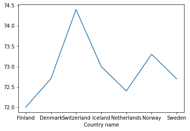

```python
# Plot the 'Healthy life expectancy' of first seven countries
countries.head(7)["Healthy life expectancy"].plot()
```

## Sorting

Sort the dataframe records in the ascending or descending order of the specified column. To sort the records in ascending order we use the method:

**Dataframe.sort_values(col_name)**

Ex: df.sort_values("name")

To sort the records in descending order we need to set the argument 'ascending' of sort_values() method to False.

Ex: df.sort_values("name", ascending=False)

**Note that this is not an in place operation and hence returns a copy of the resultant Dataframe.**

Ex: df.sort_values("name", ascending=False, inplace=True)

```python
# Sort the countries dataframe in ascending order of Social support
countries.sort_values("Social support")
```

| Country name | Regional indicator | Ladder score | Standard error of ladder score | upperwhisker | lowerwhisker | Logged GDP per capita | Social support | Healthy life expectancy | Freedom to make life choices | Generosity | Perceptions of corruption | Ladder score in Dystopia | Explained by: Log GDP per capita | Explained by: Social support | Explained by: Healthy life expectancy | Explained by: Freedom to make life choices | Explained by: Generosity | Explained by: Perceptions of corruption | Dystopia + residual |
| --- | --- | --- | --- | --- | --- | --- | --- | --- | --- | --- | --- | --- | --- | --- | --- | --- | --- | --- | --- |
| Afghanistan | South Asia | 2.523 | 0.038 | 2.596 | 2.449 | 7.695 | 0.463 | 52.493 | 0.382 | -0.102 | 0.924 | 2.43 | 0.370 | 0.000 | 0.126 | 0.000 | 0.122 | 0.010 | 1.895 |
| Benin | Sub-Saharan Africa | 5.045 | 0.073 | 5.189 | 4.901 | 8.087 | 0.489 | 54.713 | 0.757 | -0.034 | 0.661 | 2.43 | 0.507 | 0.058 | 0.196 | 0.457 | 0.166 | 0.178 | 3.482 |
| Burundi | Sub-Saharan Africa | 3.775 | 0.107 | 3.985 | 3.565 | 6.635 | 0.490 | 53.400 | 0.626 | -0.024 | 0.607 | 2.43 | 0.000 | 0.062 | 0.155 | 0.298 | 0.172 | 0.212 | 2.876 |
| Malawi | Sub-Saharan Africa | 3.600 | 0.092 | 3.781 | 3.419 | 6.958 | 0.537 | 57.948 | 0.780 | 0.038 | 0.729 | 2.43 | 0.113 | 0.168 | 0.298 | 0.484 | 0.213 | 0.134 | 2.190 |
| Haiti | Latin America and Caribbean | 3.615 | 0.173 | 3.953 | 3.276 | 7.477 | 0.540 | 55.700 | 0.593 | 0.422 | 0.721 | 2.43 | 0.294 | 0.173 | 0.227 | 0.257 | 0.463 | 0.139 | 2.060 |
| ... | ... | ... | ... | ... | ... | ... | ... | ... | ... | ... | ... | ... | ... | ... | ... | ... | ... | ... | ... |
| Norway | Western Europe | 7.392 | 0.035 | 7.462 | 7.323 | 11.053 | 0.954 | 73.300 | 0.960 | 0.093 | 0.270 | 2.43 | 1.543 | 1.108 | 0.782 | 0.703 | 0.249 | 0.427 | 2.580 |
| Denmark | Western Europe | 7.620 | 0.035 | 7.687 | 7.552 | 10.933 | 0.954 | 72.700 | 0.946 | 0.030 | 0.179 | 2.43 | 1.502 | 1.108 | 0.763 | 0.686 | 0.208 | 0.485 | 2.868 |
| Finland | Western Europe | 7.842 | 0.032 | 7.904 | 7.780 | 10.775 | 0.954 | 72.000 | 0.949 | -0.098 | 0.186 | 2.43 | 1.446 | 1.106 | 0.741 | 0.691 | 0.124 | 0.481 | 3.253 |
| Turkmenistan | Commonwealth of Independent States | 5.066 | 0.036 | 5.136 | 4.996 | 9.629 | 0.983 | 62.409 | 0.877 | 0.273 | 0.888 | 2.43 | 1.046 | 1.172 | 0.439 | 0.602 | 0.366 | 0.033 | 1.409 |
| Iceland | Western Europe | 7.554 | 0.059 | 7.670 | 7.438 | 10.878 | 0.983 | 73.000 | 0.955 | 0.160 | 0.673 | 2.43 | 1.482 | 1.172 | 0.772 | 0.698 | 0.293 | 0.170 | 2.967 |

149 rows × 19 columns

```python
# Sort the countries dataframe in descending order of Freedom to make life choices
countries.sort_values("Freedom to make life choices", ascending=False)
```

| Country name | Regional indicator | Ladder score | Standard error of ladder score | upperwhisker | lowerwhisker | Logged GDP per capita | Social support | Healthy life expectancy | Freedom to make life choices | Generosity | Perceptions of corruption | Ladder score in Dystopia | Explained by: Log GDP per capita | Explained by: Social support | Explained by: Healthy life expectancy | Explained by: Freedom to make life choices | Explained by: Generosity | Explained by: Perceptions of corruption | Dystopia + residual |
| --- | --- | --- | --- | --- | --- | --- | --- | --- | --- | --- | --- | --- | --- | --- | --- | --- | --- | --- | --- |
| Uzbekistan | Commonwealth of Independent States | 6.179 | 0.068 | 6.312 | 6.045 | 8.836 | 0.918 | 65.255 | 0.970 | 0.311 | 0.515 | 2.43 | 0.769 | 1.027 | 0.528 | 0.716 | 0.391 | 0.271 | 2.477 |
| Norway | Western Europe | 7.392 | 0.035 | 7.462 | 7.323 | 11.053 | 0.954 | 73.300 | 0.960 | 0.093 | 0.270 | 2.43 | 1.543 | 1.108 | 0.782 | 0.703 | 0.249 | 0.427 | 2.580 |
| Cambodia | Southeast Asia | 4.830 | 0.067 | 4.963 | 4.698 | 8.360 | 0.765 | 62.000 | 0.959 | 0.034 | 0.843 | 2.43 | 0.603 | 0.680 | 0.426 | 0.702 | 0.210 | 0.061 | 2.148 |
| Iceland | Western Europe | 7.554 | 0.059 | 7.670 | 7.438 | 10.878 | 0.983 | 73.000 | 0.955 | 0.160 | 0.673 | 2.43 | 1.482 | 1.172 | 0.772 | 0.698 | 0.293 | 0.170 | 2.967 |
| Finland | Western Europe | 7.842 | 0.032 | 7.904 | 7.780 | 10.775 | 0.954 | 72.000 | 0.949 | -0.098 | 0.186 | 2.43 | 1.446 | 1.106 | 0.741 | 0.691 | 0.124 | 0.481 | 3.253 |
| ... | ... | ... | ... | ... | ... | ... | ... | ... | ... | ... | ... | ... | ... | ... | ... | ... | ... | ... | ... |
| Madagascar | Sub-Saharan Africa | 4.208 | 0.072 | 4.349 | 4.068 | 7.396 | 0.686 | 59.305 | 0.552 | -0.005 | 0.803 | 2.43 | 0.266 | 0.503 | 0.341 | 0.207 | 0.185 | 0.087 | 2.620 |
| Comoros | Sub-Saharan Africa | 4.289 | 0.084 | 4.454 | 4.123 | 8.031 | 0.626 | 57.349 | 0.548 | 0.082 | 0.781 | 2.43 | 0.488 | 0.367 | 0.279 | 0.202 | 0.241 | 0.101 | 2.610 |
| Lebanon | Middle East and North Africa | 4.584 | 0.055 | 4.691 | 4.477 | 9.626 | 0.848 | 67.355 | 0.525 | -0.073 | 0.898 | 2.43 | 1.045 | 0.868 | 0.595 | 0.175 | 0.140 | 0.026 | 1.736 |
| Algeria | Middle East and North Africa | 4.887 | 0.053 | 4.991 | 4.783 | 9.342 | 0.802 | 66.005 | 0.480 | -0.067 | 0.752 | 2.43 | 0.946 | 0.765 | 0.552 | 0.119 | 0.144 | 0.120 | 2.242 |
| Afghanistan | South Asia | 2.523 | 0.038 | 2.596 | 2.449 | 7.695 | 0.463 | 52.493 | 0.382 | -0.102 | 0.924 | 2.43 | 0.370 | 0.000 | 0.126 | 0.000 | 0.122 | 0.010 | 1.895 |

149 rows × 19 columns

```python
# Sort the countries dataframe in descending order of Generosity in place
countries.sort_values("Generosity", ascending=False, inplace=True)

# Print the dataframe
countries
```

| Country name | Regional indicator | Ladder score | Standard error of ladder score | upperwhisker | lowerwhisker | Logged GDP per capita | Social support | Healthy life expectancy | Freedom to make life choices | Generosity | Perceptions of corruption | Ladder score in Dystopia | Explained by: Log GDP per capita | Explained by: Social support | Explained by: Healthy life expectancy | Explained by: Freedom to make life choices | Explained by: Generosity | Explained by: Perceptions of corruption | Dystopia + residual |
| --- | --- | --- | --- | --- | --- | --- | --- | --- | --- | --- | --- | --- | --- | --- | --- | --- | --- | --- | --- |
| Indonesia | Southeast Asia | 5.345 | 0.056 | 5.454 | 5.235 | 9.365 | 0.811 | 62.236 | 0.873 | 0.542 | 0.867 | 2.43 | 0.954 | 0.786 | 0.433 | 0.598 | 0.541 | 0.046 | 1.987 |
| Myanmar | Southeast Asia | 4.426 | 0.052 | 4.527 | 4.324 | 8.541 | 0.779 | 59.302 | 0.876 | 0.509 | 0.660 | 2.43 | 0.666 | 0.713 | 0.341 | 0.601 | 0.520 | 0.178 | 1.407 |
| Gambia | Sub-Saharan Africa | 5.051 | 0.089 | 5.225 | 4.877 | 7.686 | 0.690 | 55.160 | 0.697 | 0.424 | 0.746 | 2.43 | 0.367 | 0.511 | 0.210 | 0.384 | 0.465 | 0.123 | 2.990 |
| Haiti | Latin America and Caribbean | 3.615 | 0.173 | 3.953 | 3.276 | 7.477 | 0.540 | 55.700 | 0.593 | 0.422 | 0.721 | 2.43 | 0.294 | 0.173 | 0.227 | 0.257 | 0.463 | 0.139 | 2.060 |
| Uzbekistan | Commonwealth of Independent States | 6.179 | 0.068 | 6.312 | 6.045 | 8.836 | 0.918 | 65.255 | 0.970 | 0.311 | 0.515 | 2.43 | 0.769 | 1.027 | 0.528 | 0.716 | 0.391 | 0.271 | 2.477 |
| ... | ... | ... | ... | ... | ... | ... | ... | ... | ... | ... | ... | ... | ... | ... | ... | ... | ... | ... | ... |
| Georgia | Commonwealth of Independent States | 4.891 | 0.054 | 4.998 | 4.785 | 9.585 | 0.671 | 64.300 | 0.783 | -0.238 | 0.655 | 2.43 | 1.030 | 0.470 | 0.498 | 0.488 | 0.032 | 0.181 | 2.191 |
| Portugal | Western Europe | 5.929 | 0.055 | 6.037 | 5.821 | 10.421 | 0.879 | 72.600 | 0.892 | -0.244 | 0.887 | 2.43 | 1.323 | 0.939 | 0.760 | 0.621 | 0.029 | 0.033 | 2.225 |
| Botswana | Sub-Saharan Africa | 3.467 | 0.074 | 3.611 | 3.322 | 9.782 | 0.784 | 59.269 | 0.824 | -0.246 | 0.801 | 2.43 | 1.099 | 0.724 | 0.340 | 0.539 | 0.027 | 0.088 | 0.648 |
| Japan | East Asia | 5.940 | 0.040 | 6.020 | 5.861 | 10.611 | 0.884 | 75.100 | 0.796 | -0.258 | 0.638 | 2.43 | 1.389 | 0.949 | 0.838 | 0.504 | 0.020 | 0.192 | 2.048 |
| Greece | Western Europe | 5.723 | 0.046 | 5.813 | 5.632 | 10.279 | 0.823 | 72.600 | 0.582 | -0.288 | 0.823 | 2.43 | 1.273 | 0.811 | 0.760 | 0.243 | 0.000 | 0.074 | 2.561 |

149 rows × 19 columns

## Sorting by index

Since index is not a column of a dataframe we cannot directly use sort_values() method on the index. Instead we use the method:

**Dataframe.sort_index()**

Ex: df.sort_index()

```python
# Sort the countries by its index
countries.sort_index()
```

| Country name | Regional indicator | Ladder score | Standard error of ladder score | upperwhisker | lowerwhisker | Logged GDP per capita | Social support | Healthy life expectancy | Freedom to make life choices | Generosity | Perceptions of corruption | Ladder score in Dystopia | Explained by: Log GDP per capita | Explained by: Social support | Explained by: Healthy life expectancy | Explained by: Freedom to make life choices | Explained by: Generosity | Explained by: Perceptions of corruption | Dystopia + residual |
| --- | --- | --- | --- | --- | --- | --- | --- | --- | --- | --- | --- | --- | --- | --- | --- | --- | --- | --- | --- |
| Afghanistan | South Asia | 2.523 | 0.038 | 2.596 | 2.449 | 7.695 | 0.463 | 52.493 | 0.382 | -0.102 | 0.924 | 2.43 | 0.370 | 0.000 | 0.126 | 0.000 | 0.122 | 0.010 | 1.895 |
| Albania | Central and Eastern Europe | 5.117 | 0.059 | 5.234 | 5.001 | 9.520 | 0.697 | 68.999 | 0.785 | -0.030 | 0.901 | 2.43 | 1.008 | 0.529 | 0.646 | 0.491 | 0.168 | 0.024 | 2.250 |
| Algeria | Middle East and North Africa | 4.887 | 0.053 | 4.991 | 4.783 | 9.342 | 0.802 | 66.005 | 0.480 | -0.067 | 0.752 | 2.43 | 0.946 | 0.765 | 0.552 | 0.119 | 0.144 | 0.120 | 2.242 |
| Argentina | Latin America and Caribbean | 5.929 | 0.056 | 6.040 | 5.819 | 9.962 | 0.898 | 69.000 | 0.828 | -0.182 | 0.834 | 2.43 | 1.162 | 0.980 | 0.646 | 0.544 | 0.069 | 0.067 | 2.461 |
| Armenia | Commonwealth of Independent States | 5.283 | 0.058 | 5.397 | 5.168 | 9.487 | 0.799 | 67.055 | 0.825 | -0.168 | 0.629 | 2.43 | 0.996 | 0.758 | 0.585 | 0.540 | 0.079 | 0.198 | 2.127 |
| ... | ... | ... | ... | ... | ... | ... | ... | ... | ... | ... | ... | ... | ... | ... | ... | ... | ... | ... | ... |
| Venezuela | Latin America and Caribbean | 4.892 | 0.064 | 5.017 | 4.767 | 9.073 | 0.861 | 66.700 | 0.615 | -0.169 | 0.827 | 2.43 | 0.852 | 0.897 | 0.574 | 0.284 | 0.078 | 0.072 | 2.135 |
| Vietnam | Southeast Asia | 5.411 | 0.039 | 5.488 | 5.334 | 8.973 | 0.850 | 68.034 | 0.940 | -0.098 | 0.796 | 2.43 | 0.817 | 0.873 | 0.616 | 0.679 | 0.124 | 0.091 | 2.211 |
| Yemen | Middle East and North Africa | 3.658 | 0.070 | 3.794 | 3.521 | 7.578 | 0.832 | 57.122 | 0.602 | -0.147 | 0.800 | 2.43 | 0.329 | 0.831 | 0.272 | 0.268 | 0.092 | 0.089 | 1.776 |
| Zambia | Sub-Saharan Africa | 4.073 | 0.069 | 4.209 | 3.938 | 8.145 | 0.708 | 55.809 | 0.782 | 0.061 | 0.823 | 2.43 | 0.528 | 0.552 | 0.231 | 0.487 | 0.227 | 0.074 | 1.975 |
| Zimbabwe | Sub-Saharan Africa | 3.145 | 0.058 | 3.259 | 3.030 | 7.943 | 0.750 | 56.201 | 0.677 | -0.047 | 0.821 | 2.43 | 0.457 | 0.649 | 0.243 | 0.359 | 0.157 | 0.075 | 1.205 |

149 rows × 19 columns

## Sorting by multiple columns

We can sort the dataframe by multiple columns using the same syntax. Instead of passing one column, we pass a list of columns.

**Syntax: Dataframe.sort_values([col1_name, col2_name, ..., colN_name])**

Ex: df.sort_values(["name", "age"])

```python
# Read houses dataset
houses = pd.read_csv("./datasets/kc_house_data.csv")

# Print the dataframe
houses.head()
```

|  | id | date | price | bedrooms | bathrooms | sqft_living | sqft_lot | floors | waterfront | view | ... | grade | sqft_above | sqft_basement | yr_built | yr_renovated | zipcode | lat | long | sqft_living15 | sqft_lot15 |
| --- | --- | --- | --- | --- | --- | --- | --- | --- | --- | --- | --- | --- | --- | --- | --- | --- | --- | --- | --- | --- | --- |
| 0 | 7129300520 | 20141013T000000 | 221900.0 | 3 | 1.00 | 1180 | 5650 | 1.0 | 0 | 0 | ... | 7 | 1180 | 0 | 1955 | 0 | 98178 | 47.5112 | -122.257 | 1340 | 5650 |
| 1 | 6414100192 | 20141209T000000 | 538000.0 | 3 | 2.25 | 2570 | 7242 | 2.0 | 0 | 0 | ... | 7 | 2170 | 400 | 1951 | 1991 | 98125 | 47.7210 | -122.319 | 1690 | 7639 |
| 2 | 5631500400 | 20150225T000000 | 180000.0 | 2 | 1.00 | 770 | 10000 | 1.0 | 0 | 0 | ... | 6 | 770 | 0 | 1933 | 0 | 98028 | 47.7379 | -122.233 | 2720 | 8062 |
| 3 | 2487200875 | 20141209T000000 | 604000.0 | 4 | 3.00 | 1960 | 5000 | 1.0 | 0 | 0 | ... | 7 | 1050 | 910 | 1965 | 0 | 98136 | 47.5208 | -122.393 | 1360 | 5000 |
| 4 | 1954400510 | 20150218T000000 | 510000.0 | 3 | 2.00 | 1680 | 8080 | 1.0 | 0 | 0 | ... | 8 | 1680 | 0 | 1987 | 0 | 98074 | 47.6168 | -122.045 | 1800 | 7503 |

5 rows × 21 columns

```python
# Set in place id as index of dataframe
houses.set_index("id", inplace=True)

# Print the dataframe
houses
```

| id | date | price | bedrooms | bathrooms | sqft_living | sqft_lot | floors | waterfront | view | condition | grade | sqft_above | sqft_basement | yr_built | yr_renovated | zipcode | lat | long | sqft_living15 | sqft_lot15 |
| --- | --- | --- | --- | --- | --- | --- | --- | --- | --- | --- | --- | --- | --- | --- | --- | --- | --- | --- | --- | --- |
| 7129300520 | 20141013T000000 | 221900.0 | 3 | 1.00 | 1180 | 5650 | 1.0 | 0 | 0 | 3 | 7 | 1180 | 0 | 1955 | 0 | 98178 | 47.5112 | -122.257 | 1340 | 5650 |
| 6414100192 | 20141209T000000 | 538000.0 | 3 | 2.25 | 2570 | 7242 | 2.0 | 0 | 0 | 3 | 7 | 2170 | 400 | 1951 | 1991 | 98125 | 47.7210 | -122.319 | 1690 | 7639 |
| 5631500400 | 20150225T000000 | 180000.0 | 2 | 1.00 | 770 | 10000 | 1.0 | 0 | 0 | 3 | 6 | 770 | 0 | 1933 | 0 | 98028 | 47.7379 | -122.233 | 2720 | 8062 |
| 2487200875 | 20141209T000000 | 604000.0 | 4 | 3.00 | 1960 | 5000 | 1.0 | 0 | 0 | 5 | 7 | 1050 | 910 | 1965 | 0 | 98136 | 47.5208 | -122.393 | 1360 | 5000 |
| 1954400510 | 20150218T000000 | 510000.0 | 3 | 2.00 | 1680 | 8080 | 1.0 | 0 | 0 | 3 | 8 | 1680 | 0 | 1987 | 0 | 98074 | 47.6168 | -122.045 | 1800 | 7503 |
| ... | ... | ... | ... | ... | ... | ... | ... | ... | ... | ... | ... | ... | ... | ... | ... | ... | ... | ... | ... | ... |
| 263000018 | 20140521T000000 | 360000.0 | 3 | 2.50 | 1530 | 1131 | 3.0 | 0 | 0 | 3 | 8 | 1530 | 0 | 2009 | 0 | 98103 | 47.6993 | -122.346 | 1530 | 1509 |
| 6600060120 | 20150223T000000 | 400000.0 | 4 | 2.50 | 2310 | 5813 | 2.0 | 0 | 0 | 3 | 8 | 2310 | 0 | 2014 | 0 | 98146 | 47.5107 | -122.362 | 1830 | 7200 |
| 1523300141 | 20140623T000000 | 402101.0 | 2 | 0.75 | 1020 | 1350 | 2.0 | 0 | 0 | 3 | 7 | 1020 | 0 | 2009 | 0 | 98144 | 47.5944 | -122.299 | 1020 | 2007 |
| 291310100 | 20150116T000000 | 400000.0 | 3 | 2.50 | 1600 | 2388 | 2.0 | 0 | 0 | 3 | 8 | 1600 | 0 | 2004 | 0 | 98027 | 47.5345 | -122.069 | 1410 | 1287 |
| 1523300157 | 20141015T000000 | 325000.0 | 2 | 0.75 | 1020 | 1076 | 2.0 | 0 | 0 | 3 | 7 | 1020 | 0 | 2008 | 0 | 98144 | 47.5941 | -122.299 | 1020 | 1357 |

21613 rows × 20 columns

```python
# Sort the dataframe in descending order of price
houses.sort_values("price", ascending=False)
```

| id | date | price | bedrooms | bathrooms | sqft_living | sqft_lot | floors | waterfront | view | condition | grade | sqft_above | sqft_basement | yr_built | yr_renovated | zipcode | lat | long | sqft_living15 | sqft_lot15 |
| --- | --- | --- | --- | --- | --- | --- | --- | --- | --- | --- | --- | --- | --- | --- | --- | --- | --- | --- | --- | --- |
| 6762700020 | 20141013T000000 | 7700000.0 | 6 | 8.00 | 12050 | 27600 | 2.5 | 0 | 3 | 4 | 13 | 8570 | 3480 | 1910 | 1987 | 98102 | 47.6298 | -122.323 | 3940 | 8800 |
| 9808700762 | 20140611T000000 | 7062500.0 | 5 | 4.50 | 10040 | 37325 | 2.0 | 1 | 2 | 3 | 11 | 7680 | 2360 | 1940 | 2001 | 98004 | 47.6500 | -122.214 | 3930 | 25449 |
| 9208900037 | 20140919T000000 | 6885000.0 | 6 | 7.75 | 9890 | 31374 | 2.0 | 0 | 4 | 3 | 13 | 8860 | 1030 | 2001 | 0 | 98039 | 47.6305 | -122.240 | 4540 | 42730 |
| 2470100110 | 20140804T000000 | 5570000.0 | 5 | 5.75 | 9200 | 35069 | 2.0 | 0 | 0 | 3 | 13 | 6200 | 3000 | 2001 | 0 | 98039 | 47.6289 | -122.233 | 3560 | 24345 |
| 8907500070 | 20150413T000000 | 5350000.0 | 5 | 5.00 | 8000 | 23985 | 2.0 | 0 | 4 | 3 | 12 | 6720 | 1280 | 2009 | 0 | 98004 | 47.6232 | -122.220 | 4600 | 21750 |
| ... | ... | ... | ... | ... | ... | ... | ... | ... | ... | ... | ... | ... | ... | ... | ... | ... | ... | ... | ... | ... |
| 3883800011 | 20141105T000000 | 82000.0 | 3 | 1.00 | 860 | 10426 | 1.0 | 0 | 0 | 3 | 6 | 860 | 0 | 1954 | 0 | 98146 | 47.4987 | -122.341 | 1140 | 11250 |
| 3028200080 | 20150324T000000 | 81000.0 | 2 | 1.00 | 730 | 9975 | 1.0 | 0 | 0 | 1 | 5 | 730 | 0 | 1943 | 0 | 98168 | 47.4808 | -122.315 | 860 | 9000 |
| 8658300340 | 20140523T000000 | 80000.0 | 1 | 0.75 | 430 | 5050 | 1.0 | 0 | 0 | 2 | 4 | 430 | 0 | 1912 | 0 | 98014 | 47.6499 | -121.909 | 1200 | 7500 |
| 40000362 | 20140506T000000 | 78000.0 | 2 | 1.00 | 780 | 16344 | 1.0 | 0 | 0 | 1 | 5 | 780 | 0 | 1942 | 0 | 98168 | 47.4739 | -122.280 | 1700 | 10387 |
| 3421079032 | 20150217T000000 | 75000.0 | 1 | 0.00 | 670 | 43377 | 1.0 | 0 | 0 | 3 | 3 | 670 | 0 | 1966 | 0 | 98022 | 47.2638 | -121.906 | 1160 | 42882 |

21613 rows × 20 columns

```python
# Sort the dataframe in descending order of bedrooms
houses.sort_values("bedrooms", ascending=False)
```

| id | date | price | bedrooms | bathrooms | sqft_living | sqft_lot | floors | waterfront | view | condition | grade | sqft_above | sqft_basement | yr_built | yr_renovated | zipcode | lat | long | sqft_living15 | sqft_lot15 |
| --- | --- | --- | --- | --- | --- | --- | --- | --- | --- | --- | --- | --- | --- | --- | --- | --- | --- | --- | --- | --- |
| 2402100895 | 20140625T000000 | 640000.0 | 33 | 1.75 | 1620 | 6000 | 1.0 | 0 | 0 | 5 | 7 | 1040 | 580 | 1947 | 0 | 98103 | 47.6878 | -122.331 | 1330 | 4700 |
| 1773100755 | 20140821T000000 | 520000.0 | 11 | 3.00 | 3000 | 4960 | 2.0 | 0 | 0 | 3 | 7 | 2400 | 600 | 1918 | 1999 | 98106 | 47.5560 | -122.363 | 1420 | 4960 |
| 5566100170 | 20141029T000000 | 650000.0 | 10 | 2.00 | 3610 | 11914 | 2.0 | 0 | 0 | 4 | 7 | 3010 | 600 | 1958 | 0 | 98006 | 47.5705 | -122.175 | 2040 | 11914 |
| 627300145 | 20140814T000000 | 1148000.0 | 10 | 5.25 | 4590 | 10920 | 1.0 | 0 | 2 | 3 | 9 | 2500 | 2090 | 2008 | 0 | 98004 | 47.5861 | -122.113 | 2730 | 10400 |
| 8812401450 | 20141229T000000 | 660000.0 | 10 | 3.00 | 2920 | 3745 | 2.0 | 0 | 0 | 4 | 7 | 1860 | 1060 | 1913 | 0 | 98105 | 47.6635 | -122.320 | 1810 | 3745 |
| ... | ... | ... | ... | ... | ... | ... | ... | ... | ... | ... | ... | ... | ... | ... | ... | ... | ... | ... | ... | ... |
| 3980300371 | 20140926T000000 | 142000.0 | 0 | 0.00 | 290 | 20875 | 1.0 | 0 | 0 | 1 | 1 | 290 | 0 | 1963 | 0 | 98024 | 47.5308 | -121.888 | 1620 | 22850 |
| 2310060040 | 20140925T000000 | 240000.0 | 0 | 2.50 | 1810 | 5669 | 2.0 | 0 | 0 | 3 | 7 | 1810 | 0 | 2003 | 0 | 98038 | 47.3493 | -122.053 | 1810 | 5685 |
| 6306400140 | 20140612T000000 | 1095000.0 | 0 | 0.00 | 3064 | 4764 | 3.5 | 0 | 2 | 3 | 7 | 3064 | 0 | 1990 | 0 | 98102 | 47.6362 | -122.322 | 2360 | 4000 |
| 2569500210 | 20141117T000000 | 339950.0 | 0 | 2.50 | 2290 | 8319 | 2.0 | 0 | 0 | 3 | 8 | 2290 | 0 | 1985 | 0 | 98042 | 47.3473 | -122.151 | 2500 | 8751 |
| 3374500520 | 20150429T000000 | 355000.0 | 0 | 0.00 | 2460 | 8049 | 2.0 | 0 | 0 | 3 | 8 | 2460 | 0 | 1990 | 0 | 98031 | 47.4095 | -122.168 | 2520 | 8050 |

21613 rows × 20 columns

```python
# Sort the dataframe in descending order of bedrooms and if there is a tie sort them in the descending order of their price
houses.sort_values(["bedrooms", "price"], ascending=False)
```

| id | date | price | bedrooms | bathrooms | sqft_living | sqft_lot | floors | waterfront | view | condition | grade | sqft_above | sqft_basement | yr_built | yr_renovated | zipcode | lat | long | sqft_living15 | sqft_lot15 |
| --- | --- | --- | --- | --- | --- | --- | --- | --- | --- | --- | --- | --- | --- | --- | --- | --- | --- | --- | --- | --- |
| 2402100895 | 20140625T000000 | 640000.0 | 33 | 1.75 | 1620 | 6000 | 1.0 | 0 | 0 | 5 | 7 | 1040 | 580 | 1947 | 0 | 98103 | 47.6878 | -122.331 | 1330 | 4700 |
| 1773100755 | 20140821T000000 | 520000.0 | 11 | 3.00 | 3000 | 4960 | 2.0 | 0 | 0 | 3 | 7 | 2400 | 600 | 1918 | 1999 | 98106 | 47.5560 | -122.363 | 1420 | 4960 |
| 627300145 | 20140814T000000 | 1148000.0 | 10 | 5.25 | 4590 | 10920 | 1.0 | 0 | 2 | 3 | 9 | 2500 | 2090 | 2008 | 0 | 98004 | 47.5861 | -122.113 | 2730 | 10400 |
| 8812401450 | 20141229T000000 | 660000.0 | 10 | 3.00 | 2920 | 3745 | 2.0 | 0 | 0 | 4 | 7 | 1860 | 1060 | 1913 | 0 | 98105 | 47.6635 | -122.320 | 1810 | 3745 |
| 5566100170 | 20141029T000000 | 650000.0 | 10 | 2.00 | 3610 | 11914 | 2.0 | 0 | 0 | 4 | 7 | 3010 | 600 | 1958 | 0 | 98006 | 47.5705 | -122.175 | 2040 | 11914 |
| ... | ... | ... | ... | ... | ... | ... | ... | ... | ... | ... | ... | ... | ... | ... | ... | ... | ... | ... | ... | ... |
| 2310060040 | 20140925T000000 | 240000.0 | 0 | 2.50 | 1810 | 5669 | 2.0 | 0 | 0 | 3 | 7 | 1810 | 0 | 2003 | 0 | 98038 | 47.3493 | -122.053 | 1810 | 5685 |
| 7849202190 | 20141223T000000 | 235000.0 | 0 | 0.00 | 1470 | 4800 | 2.0 | 0 | 0 | 3 | 7 | 1470 | 0 | 1996 | 0 | 98065 | 47.5265 | -121.828 | 1060 | 7200 |
| 6896300380 | 20141002T000000 | 228000.0 | 0 | 1.00 | 390 | 5900 | 1.0 | 0 | 0 | 2 | 4 | 390 | 0 | 1953 | 0 | 98118 | 47.5260 | -122.261 | 2170 | 6000 |
| 3980300371 | 20140926T000000 | 142000.0 | 0 | 0.00 | 290 | 20875 | 1.0 | 0 | 0 | 1 | 1 | 290 | 0 | 1963 | 0 | 98024 | 47.5308 | -121.888 | 1620 | 22850 |
| 9543000205 | 20150413T000000 | 139950.0 | 0 | 0.00 | 844 | 4269 | 1.0 | 0 | 0 | 4 | 7 | 844 | 0 | 1913 | 0 | 98001 | 47.2781 | -122.250 | 1380 | 9600 |

21613 rows × 20 columns

## Selecting rows

We can select rows from a Dataframe based on their label/index using the following methods:

1) **Dataframe.loc["label"]**: Access a group of records based on their label.

Ex: df.loc["group1"], returns all the records with label "group1".

2) **Dataframe.iloc[position]**: Access a group of records based on their position

Ex: df.iloc[0], returns first row (index 0).

**Note: loc looks for values whereas iloc looks for position**

We can also make use of Python slicing to extract records within a range

3) **Dataframe.loc[start:end] (or) Dataframe.iloc[start:end]**

Ex: df.loc["group1":"group3"], returns all the records of dataframe starting with label "group1" upto label "group3".

Ex: df.loc[0:9], returns all the records of dataframe whose position are within the range 0 to 9.

```python
# Extract details about country 'India'
countries.loc["India"]
```

```
Regional indicator                            South Asia
Ladder score                                       3.819
Standard error of ladder score                     0.026
upperwhisker                                       3.869
lowerwhisker                                       3.769
Logged GDP per capita                              8.755
Social support                                     0.603
Healthy life expectancy                           60.633
Freedom to make life choices                       0.893
Generosity                                         0.089
Perceptions of corruption                          0.774
Ladder score in Dystopia                            2.43
Explained by: Log GDP per capita                   0.741
Explained by: Social support                       0.316
Explained by: Healthy life expectancy              0.383
Explained by: Freedom to make life choices         0.622
Explained by: Generosity                           0.246
Explained by: Perceptions of corruption            0.106
Dystopia + residual                                1.405
Name: India, dtype: object
```

```python
# Extract details about country 'India' horizontally
countries.loc[["India"]]
```

| Country name | Regional indicator | Ladder score | Standard error of ladder score | upperwhisker | lowerwhisker | Logged GDP per capita | Social support | Healthy life expectancy | Freedom to make life choices | Generosity | Perceptions of corruption | Ladder score in Dystopia | Explained by: Log GDP per capita | Explained by: Social support | Explained by: Healthy life expectancy | Explained by: Freedom to make life choices | Explained by: Generosity | Explained by: Perceptions of corruption | Dystopia + residual |
| --- | --- | --- | --- | --- | --- | --- | --- | --- | --- | --- | --- | --- | --- | --- | --- | --- | --- | --- | --- |
| India | South Asia | 3.819 | 0.026 | 3.869 | 3.769 | 8.755 | 0.603 | 60.633 | 0.893 | 0.089 | 0.774 | 2.43 | 0.741 | 0.316 | 0.383 | 0.622 | 0.246 | 0.106 | 1.405 |

```python
# Extract details about any 5 Asian countries
countries.loc[["India", "Pakistan", "Bangladesh", "Sri Lanka", "Nepal"]]
```

| Country name | Regional indicator | Ladder score | Standard error of ladder score | upperwhisker | lowerwhisker | Logged GDP per capita | Social support | Healthy life expectancy | Freedom to make life choices | Generosity | Perceptions of corruption | Ladder score in Dystopia | Explained by: Log GDP per capita | Explained by: Social support | Explained by: Healthy life expectancy | Explained by: Freedom to make life choices | Explained by: Generosity | Explained by: Perceptions of corruption | Dystopia + residual |
| --- | --- | --- | --- | --- | --- | --- | --- | --- | --- | --- | --- | --- | --- | --- | --- | --- | --- | --- | --- |
| India | South Asia | 3.819 | 0.026 | 3.869 | 3.769 | 8.755 | 0.603 | 60.633 | 0.893 | 0.089 | 0.774 | 2.43 | 0.741 | 0.316 | 0.383 | 0.622 | 0.246 | 0.106 | 1.405 |
| Pakistan | South Asia | 4.934 | 0.068 | 5.066 | 4.802 | 8.458 | 0.651 | 58.709 | 0.726 | 0.098 | 0.787 | 2.43 | 0.637 | 0.423 | 0.322 | 0.418 | 0.252 | 0.097 | 2.784 |
| Bangladesh | South Asia | 5.025 | 0.046 | 5.115 | 4.934 | 8.454 | 0.693 | 64.800 | 0.877 | -0.041 | 0.682 | 2.43 | 0.635 | 0.520 | 0.514 | 0.603 | 0.161 | 0.164 | 2.427 |
| Sri Lanka | South Asia | 4.325 | 0.066 | 4.454 | 4.196 | 9.470 | 0.827 | 67.299 | 0.841 | 0.079 | 0.863 | 2.43 | 0.990 | 0.820 | 0.593 | 0.559 | 0.239 | 0.049 | 1.075 |
| Nepal | South Asia | 5.269 | 0.070 | 5.406 | 5.132 | 8.120 | 0.774 | 64.233 | 0.782 | 0.152 | 0.727 | 2.43 | 0.519 | 0.702 | 0.496 | 0.488 | 0.287 | 0.135 | 2.642 |

```python
# Extract details within a range
tnc.loc[0:5]
```

|  | pclass | survived | name | gender | age | sibsp | parch | ticket | fare | cabin | embarked | boat | body | home.dest |
| --- | --- | --- | --- | --- | --- | --- | --- | --- | --- | --- | --- | --- | --- | --- |
| 0 | 1 | 1 | Allen, Miss. Elisabeth Walton | female | 29 | 0 | 0 | 24160 | 211.3375 | B5 | S | 2 | ? | St Louis, MO |
| 1 | 1 | 1 | Allison, Master. Hudson Trevor | male | 0.9167 | 1 | 2 | 113781 | 151.55 | C22 C26 | S | 11 | ? | Montreal, PQ / Chesterville, ON |
| 2 | 1 | 0 | Allison, Miss. Helen Loraine | female | 2 | 1 | 2 | 113781 | 151.55 | C22 C26 | S | ? | ? | Montreal, PQ / Chesterville, ON |
| 3 | 1 | 0 | Allison, Mr. Hudson Joshua Creighton | male | 30 | 1 | 2 | 113781 | 151.55 | C22 C26 | S | ? | 135 | Montreal, PQ / Chesterville, ON |
| 4 | 1 | 0 | Allison, Mrs. Hudson J C (Bessie Waldo Daniels) | female | 25 | 1 | 2 | 113781 | 151.55 | C22 C26 | S | ? | ? | Montreal, PQ / Chesterville, ON |
| 5 | 1 | 1 | Anderson, Mr. Harry | male | 48 | 0 | 0 | 19952 | 26.55 | E12 | S | 3 | ? | New York, NY |

```python
# Extract details of countries from 'America' to 'India' when sorted alphabetically
countries.sort_index().loc["America":"India"]
```

| Country name | Regional indicator | Ladder score | Standard error of ladder score | upperwhisker | lowerwhisker | Logged GDP per capita | Social support | Healthy life expectancy | Freedom to make life choices | Generosity | Perceptions of corruption | Ladder score in Dystopia | Explained by: Log GDP per capita | Explained by: Social support | Explained by: Healthy life expectancy | Explained by: Freedom to make life choices | Explained by: Generosity | Explained by: Perceptions of corruption | Dystopia + residual |
| --- | --- | --- | --- | --- | --- | --- | --- | --- | --- | --- | --- | --- | --- | --- | --- | --- | --- | --- | --- |
| Argentina | Latin America and Caribbean | 5.929 | 0.056 | 6.040 | 5.819 | 9.962 | 0.898 | 69.000 | 0.828 | -0.182 | 0.834 | 2.43 | 1.162 | 0.980 | 0.646 | 0.544 | 0.069 | 0.067 | 2.461 |
| Armenia | Commonwealth of Independent States | 5.283 | 0.058 | 5.397 | 5.168 | 9.487 | 0.799 | 67.055 | 0.825 | -0.168 | 0.629 | 2.43 | 0.996 | 0.758 | 0.585 | 0.540 | 0.079 | 0.198 | 2.127 |
| Australia | North America and ANZ | 7.183 | 0.041 | 7.265 | 7.102 | 10.796 | 0.940 | 73.900 | 0.914 | 0.159 | 0.442 | 2.43 | 1.453 | 1.076 | 0.801 | 0.647 | 0.291 | 0.317 | 2.598 |
| Austria | Western Europe | 7.268 | 0.036 | 7.337 | 7.198 | 10.906 | 0.934 | 73.300 | 0.908 | 0.042 | 0.481 | 2.43 | 1.492 | 1.062 | 0.782 | 0.640 | 0.215 | 0.292 | 2.784 |
| Azerbaijan | Commonwealth of Independent States | 5.171 | 0.040 | 5.250 | 5.091 | 9.569 | 0.836 | 65.656 | 0.814 | -0.223 | 0.506 | 2.43 | 1.025 | 0.841 | 0.541 | 0.526 | 0.043 | 0.276 | 1.919 |
| Bahrain | Middle East and North Africa | 6.647 | 0.068 | 6.779 | 6.514 | 10.669 | 0.862 | 69.495 | 0.925 | 0.089 | 0.722 | 2.43 | 1.409 | 0.899 | 0.662 | 0.661 | 0.246 | 0.139 | 2.631 |
| Bangladesh | South Asia | 5.025 | 0.046 | 5.115 | 4.934 | 8.454 | 0.693 | 64.800 | 0.877 | -0.041 | 0.682 | 2.43 | 0.635 | 0.520 | 0.514 | 0.603 | 0.161 | 0.164 | 2.427 |
| Belarus | Commonwealth of Independent States | 5.534 | 0.047 | 5.625 | 5.442 | 9.853 | 0.910 | 66.253 | 0.650 | -0.180 | 0.627 | 2.43 | 1.124 | 1.007 | 0.560 | 0.326 | 0.070 | 0.199 | 2.247 |
| Belgium | Western Europe | 6.834 | 0.034 | 6.901 | 6.767 | 10.823 | 0.906 | 72.199 | 0.783 | -0.153 | 0.646 | 2.43 | 1.463 | 0.998 | 0.747 | 0.489 | 0.088 | 0.187 | 2.862 |
| Benin | Sub-Saharan Africa | 5.045 | 0.073 | 5.189 | 4.901 | 8.087 | 0.489 | 54.713 | 0.757 | -0.034 | 0.661 | 2.43 | 0.507 | 0.058 | 0.196 | 0.457 | 0.166 | 0.178 | 3.482 |
| Bolivia | Latin America and Caribbean | 5.716 | 0.053 | 5.819 | 5.613 | 9.046 | 0.810 | 63.901 | 0.875 | -0.077 | 0.839 | 2.43 | 0.842 | 0.782 | 0.486 | 0.600 | 0.138 | 0.064 | 2.805 |
| Bosnia and Herzegovina | Central and Eastern Europe | 5.813 | 0.050 | 5.911 | 5.715 | 9.590 | 0.870 | 68.098 | 0.706 | 0.113 | 0.931 | 2.43 | 1.032 | 0.919 | 0.618 | 0.395 | 0.261 | 0.005 | 2.583 |
| Botswana | Sub-Saharan Africa | 3.467 | 0.074 | 3.611 | 3.322 | 9.782 | 0.784 | 59.269 | 0.824 | -0.246 | 0.801 | 2.43 | 1.099 | 0.724 | 0.340 | 0.539 | 0.027 | 0.088 | 0.648 |
| Brazil | Latin America and Caribbean | 6.330 | 0.043 | 6.415 | 6.245 | 9.577 | 0.882 | 66.601 | 0.804 | -0.071 | 0.756 | 2.43 | 1.028 | 0.944 | 0.571 | 0.514 | 0.142 | 0.117 | 3.015 |
| Bulgaria | Central and Eastern Europe | 5.266 | 0.054 | 5.371 | 5.160 | 10.016 | 0.931 | 67.000 | 0.788 | -0.096 | 0.932 | 2.43 | 1.181 | 1.055 | 0.583 | 0.494 | 0.125 | 0.005 | 1.823 |
| Burkina Faso | Sub-Saharan Africa | 4.834 | 0.081 | 4.993 | 4.675 | 7.678 | 0.672 | 54.151 | 0.695 | -0.009 | 0.748 | 2.43 | 0.364 | 0.472 | 0.179 | 0.381 | 0.182 | 0.122 | 3.133 |
| Burundi | Sub-Saharan Africa | 3.775 | 0.107 | 3.985 | 3.565 | 6.635 | 0.490 | 53.400 | 0.626 | -0.024 | 0.607 | 2.43 | 0.000 | 0.062 | 0.155 | 0.298 | 0.172 | 0.212 | 2.876 |
| Cambodia | Southeast Asia | 4.830 | 0.067 | 4.963 | 4.698 | 8.360 | 0.765 | 62.000 | 0.959 | 0.034 | 0.843 | 2.43 | 0.603 | 0.680 | 0.426 | 0.702 | 0.210 | 0.061 | 2.148 |
| Cameroon | Sub-Saharan Africa | 5.142 | 0.074 | 5.288 | 4.996 | 8.189 | 0.710 | 53.515 | 0.731 | 0.026 | 0.848 | 2.43 | 0.543 | 0.556 | 0.159 | 0.425 | 0.205 | 0.058 | 3.195 |
| Canada | North America and ANZ | 7.103 | 0.042 | 7.185 | 7.021 | 10.776 | 0.926 | 73.800 | 0.915 | 0.089 | 0.415 | 2.43 | 1.447 | 1.044 | 0.798 | 0.648 | 0.246 | 0.335 | 2.585 |
| Chad | Sub-Saharan Africa | 4.355 | 0.094 | 4.540 | 4.171 | 7.364 | 0.619 | 48.478 | 0.579 | 0.041 | 0.807 | 2.43 | 0.255 | 0.353 | 0.000 | 0.240 | 0.215 | 0.084 | 3.209 |
| Chile | Latin America and Caribbean | 6.172 | 0.046 | 6.262 | 6.081 | 10.071 | 0.882 | 70.000 | 0.742 | -0.044 | 0.830 | 2.43 | 1.200 | 0.946 | 0.678 | 0.438 | 0.159 | 0.070 | 2.682 |
| China | East Asia | 5.339 | 0.029 | 5.397 | 5.281 | 9.673 | 0.811 | 69.593 | 0.904 | -0.146 | 0.755 | 2.43 | 1.061 | 0.785 | 0.665 | 0.636 | 0.093 | 0.117 | 1.982 |
| Colombia | Latin America and Caribbean | 6.012 | 0.061 | 6.132 | 5.892 | 9.557 | 0.847 | 68.001 | 0.837 | -0.135 | 0.841 | 2.43 | 1.021 | 0.866 | 0.615 | 0.554 | 0.100 | 0.063 | 2.794 |
| Comoros | Sub-Saharan Africa | 4.289 | 0.084 | 4.454 | 4.123 | 8.031 | 0.626 | 57.349 | 0.548 | 0.082 | 0.781 | 2.43 | 0.488 | 0.367 | 0.279 | 0.202 | 0.241 | 0.101 | 2.610 |
| Congo (Brazzaville) | Sub-Saharan Africa | 5.342 | 0.097 | 5.533 | 5.151 | 8.117 | 0.636 | 58.221 | 0.695 | -0.068 | 0.745 | 2.43 | 0.518 | 0.392 | 0.307 | 0.381 | 0.144 | 0.124 | 3.476 |
| Costa Rica | Latin America and Caribbean | 7.069 | 0.056 | 7.179 | 6.960 | 9.880 | 0.891 | 71.400 | 0.934 | -0.126 | 0.809 | 2.43 | 1.134 | 0.966 | 0.722 | 0.673 | 0.105 | 0.083 | 3.387 |
| Croatia | Central and Eastern Europe | 5.882 | 0.048 | 5.975 | 5.788 | 10.217 | 0.924 | 70.799 | 0.754 | -0.118 | 0.939 | 2.43 | 1.251 | 1.039 | 0.703 | 0.453 | 0.111 | 0.000 | 2.325 |
| Cyprus | Western Europe | 6.223 | 0.049 | 6.319 | 6.128 | 10.576 | 0.802 | 73.898 | 0.763 | -0.015 | 0.844 | 2.43 | 1.377 | 0.765 | 0.801 | 0.464 | 0.178 | 0.061 | 2.578 |
| Czech Republic | Central and Eastern Europe | 6.965 | 0.049 | 7.062 | 6.868 | 10.556 | 0.947 | 70.807 | 0.858 | -0.208 | 0.868 | 2.43 | 1.370 | 1.090 | 0.703 | 0.580 | 0.052 | 0.046 | 3.124 |
| Denmark | Western Europe | 7.620 | 0.035 | 7.687 | 7.552 | 10.933 | 0.954 | 72.700 | 0.946 | 0.030 | 0.179 | 2.43 | 1.502 | 1.108 | 0.763 | 0.686 | 0.208 | 0.485 | 2.868 |
| Dominican Republic | Latin America and Caribbean | 5.545 | 0.071 | 5.685 | 5.405 | 9.802 | 0.853 | 66.102 | 0.860 | -0.133 | 0.714 | 2.43 | 1.106 | 0.879 | 0.555 | 0.581 | 0.101 | 0.144 | 2.178 |
| Ecuador | Latin America and Caribbean | 5.764 | 0.057 | 5.875 | 5.653 | 9.313 | 0.821 | 68.800 | 0.842 | -0.124 | 0.843 | 2.43 | 0.935 | 0.806 | 0.640 | 0.560 | 0.107 | 0.062 | 2.653 |
| Egypt | Middle East and North Africa | 4.283 | 0.045 | 4.371 | 4.195 | 9.367 | 0.750 | 61.998 | 0.749 | -0.182 | 0.795 | 2.43 | 0.954 | 0.647 | 0.426 | 0.446 | 0.069 | 0.092 | 1.648 |
| El Salvador | Latin America and Caribbean | 6.061 | 0.065 | 6.188 | 5.933 | 9.054 | 0.762 | 66.402 | 0.888 | -0.110 | 0.688 | 2.43 | 0.845 | 0.675 | 0.565 | 0.615 | 0.116 | 0.160 | 3.085 |
| Estonia | Central and Eastern Europe | 6.189 | 0.038 | 6.263 | 6.115 | 10.481 | 0.941 | 68.800 | 0.909 | -0.106 | 0.527 | 2.43 | 1.344 | 1.079 | 0.640 | 0.641 | 0.119 | 0.263 | 2.103 |
| Ethiopia | Sub-Saharan Africa | 4.275 | 0.051 | 4.374 | 4.175 | 7.694 | 0.764 | 59.000 | 0.752 | 0.082 | 0.761 | 2.43 | 0.370 | 0.679 | 0.331 | 0.451 | 0.241 | 0.114 | 2.089 |
| Finland | Western Europe | 7.842 | 0.032 | 7.904 | 7.780 | 10.775 | 0.954 | 72.000 | 0.949 | -0.098 | 0.186 | 2.43 | 1.446 | 1.106 | 0.741 | 0.691 | 0.124 | 0.481 | 3.253 |
| France | Western Europe | 6.690 | 0.037 | 6.762 | 6.618 | 10.704 | 0.942 | 74.000 | 0.822 | -0.147 | 0.571 | 2.43 | 1.421 | 1.081 | 0.804 | 0.536 | 0.092 | 0.235 | 2.521 |
| Gabon | Sub-Saharan Africa | 4.852 | 0.075 | 4.998 | 4.706 | 9.603 | 0.776 | 59.962 | 0.731 | -0.200 | 0.840 | 2.43 | 1.037 | 0.707 | 0.362 | 0.424 | 0.058 | 0.064 | 2.201 |
| Gambia | Sub-Saharan Africa | 5.051 | 0.089 | 5.225 | 4.877 | 7.686 | 0.690 | 55.160 | 0.697 | 0.424 | 0.746 | 2.43 | 0.367 | 0.511 | 0.210 | 0.384 | 0.465 | 0.123 | 2.990 |
| Georgia | Commonwealth of Independent States | 4.891 | 0.054 | 4.998 | 4.785 | 9.585 | 0.671 | 64.300 | 0.783 | -0.238 | 0.655 | 2.43 | 1.030 | 0.470 | 0.498 | 0.488 | 0.032 | 0.181 | 2.191 |
| Germany | Western Europe | 7.155 | 0.040 | 7.232 | 7.077 | 10.873 | 0.903 | 72.500 | 0.875 | 0.011 | 0.460 | 2.43 | 1.480 | 0.993 | 0.757 | 0.600 | 0.195 | 0.306 | 2.824 |
| Ghana | Sub-Saharan Africa | 5.088 | 0.067 | 5.219 | 4.958 | 8.580 | 0.727 | 57.586 | 0.807 | 0.123 | 0.848 | 2.43 | 0.680 | 0.595 | 0.287 | 0.517 | 0.268 | 0.058 | 2.684 |
| Greece | Western Europe | 5.723 | 0.046 | 5.813 | 5.632 | 10.279 | 0.823 | 72.600 | 0.582 | -0.288 | 0.823 | 2.43 | 1.273 | 0.811 | 0.760 | 0.243 | 0.000 | 0.074 | 2.561 |
| Guatemala | Latin America and Caribbean | 6.435 | 0.073 | 6.577 | 6.292 | 9.053 | 0.813 | 64.958 | 0.906 | -0.038 | 0.775 | 2.43 | 0.845 | 0.790 | 0.519 | 0.638 | 0.163 | 0.105 | 3.375 |
| Guinea | Sub-Saharan Africa | 4.984 | 0.090 | 5.160 | 4.808 | 7.838 | 0.639 | 55.008 | 0.697 | 0.095 | 0.766 | 2.43 | 0.420 | 0.399 | 0.206 | 0.384 | 0.250 | 0.111 | 3.216 |
| Haiti | Latin America and Caribbean | 3.615 | 0.173 | 3.953 | 3.276 | 7.477 | 0.540 | 55.700 | 0.593 | 0.422 | 0.721 | 2.43 | 0.294 | 0.173 | 0.227 | 0.257 | 0.463 | 0.139 | 2.060 |
| Honduras | Latin America and Caribbean | 5.919 | 0.082 | 6.081 | 5.758 | 8.648 | 0.812 | 67.300 | 0.857 | 0.081 | 0.809 | 2.43 | 0.703 | 0.787 | 0.593 | 0.578 | 0.241 | 0.083 | 2.934 |
| Hong Kong S.A.R. of China | East Asia | 5.477 | 0.049 | 5.573 | 5.380 | 11.000 | 0.836 | 76.820 | 0.717 | 0.067 | 0.403 | 2.43 | 1.525 | 0.841 | 0.893 | 0.408 | 0.232 | 0.342 | 1.236 |
| Hungary | Central and Eastern Europe | 5.992 | 0.047 | 6.085 | 5.899 | 10.358 | 0.943 | 68.000 | 0.755 | -0.186 | 0.876 | 2.43 | 1.301 | 1.083 | 0.615 | 0.454 | 0.067 | 0.040 | 2.432 |
| Iceland | Western Europe | 7.554 | 0.059 | 7.670 | 7.438 | 10.878 | 0.983 | 73.000 | 0.955 | 0.160 | 0.673 | 2.43 | 1.482 | 1.172 | 0.772 | 0.698 | 0.293 | 0.170 | 2.967 |
| India | South Asia | 3.819 | 0.026 | 3.869 | 3.769 | 8.755 | 0.603 | 60.633 | 0.893 | 0.089 | 0.774 | 2.43 | 0.741 | 0.316 | 0.383 | 0.622 | 0.246 | 0.106 | 1.405 |